# Predict Activity Quality from Activity Monitors

Laurent VAYLET

Feb 13, 2015

# Background

Using devices such as *Jawbone Up*, *Nike FuelBand* and *Fitbit*, it is now possible to collect a large amount of data about personal activity relatively inexpensively. These type of devices are part of the quantified self movement – a group of enthusiasts who take measurements about themselves regularly to improve their health, to find patterns in their behavior, or because they are tech geeks. One thing that people regularly do is quantify how *much* of a particular activity they do, but they rarely quantify *how well they do it*. In this project, our goal will be to use data from accelerometers on the belt, forearm, arm, and dumbell of 6 participants. They were asked to perform barbell lifts correctly and incorrectly in 5 different ways. More information is available from the website here: http://groupware.les.inf.puc-rio.br/har (see the section on the Weight Lifting Exercise Dataset).

# Objective

The goal of this project is to predict the manner in which the 6 participants did the exercise. This corresponds to the “classe” variable in the training set. Any of the other variables can be used to predict with.

This report describes how the model is built, how cross validation was used, what the expected out of sample error is, and why the choices were made. The prediction model will also be used to predict 20 different test cases.

# Approach

1. Download and read training/test data
2. Clean data by removing unnecessary variables (columns with a lot of NA values, user names, timestamps…)
3. Slice training data for cross-validation
4. Use PCA to reduce the number of covariates
5. Train a Random Forest model on dimensionality-reduced training set
6. Assess model performance on validation set
7. Assess model performance on test set

# Download and Read Rata

If necessary, download both data set for training and testing:

```r
if (!file.exists("./pml-training.csv")) {
  download.file("http://d396qusza40orc.cloudfront.net/predmachlearn/pml-training.csv",
                destfile = "./pml-training.csv")
}
if (!file.exists("./pml-testing.csv")) {
  download.file("http://d396qusza40orc.cloudfront.net/predmachlearn/pml-testing.csv",
                destfile = "./pml-testing.csv")
}
```

Read training and test data sets, replacing any empty value with NA (that will be useful later on when removing columns with lots of NA values):

```r
training.raw <- read.csv("pml-training.csv", na.strings=c("","NA"))
testing.raw <- read.csv("pml-testing.csv", na.string=c("","NA"))
```

# Clean Data

Display structure of training data set in order to quickly get some insight in a compact form:

```r
str(training.raw)
```

```
## 'data.frame':    19622 obs. of  160 variables:
##  $ X                       : int  1 2 3 4 5 6 7 8 9 10 ...
##  $ user_name               : Factor w/ 6 levels "adelmo","carlitos",..: 2 2 2 2 2 2 2 2 2 2 ...
##  $ raw_timestamp_part_1    : int  1323084231 1323084231 1323084231 1323084232 1323084232 1323084232 1323084232 1323084232 1323084232 1323084232 ...
##  $ raw_timestamp_part_2    : int  788290 808298 820366 120339 196328 304277 368296 440390 484323 484434 ...
##  $ cvtd_timestamp          : Factor w/ 20 levels "02/12/2011 13:32",..: 9 9 9 9 9 9 9 9 9 9 ...
##  $ new_window              : Factor w/ 2 levels "no","yes": 1 1 1 1 1 1 1 1 1 1 ...
##  $ num_window              : int  11 11 11 12 12 12 12 12 12 12 ...
##  $ roll_belt               : num  1.41 1.41 1.42 1.48 1.48 1.45 1.42 1.42 1.43 1.45 ...
##  $ pitch_belt              : num  8.07 8.07 8.07 8.05 8.07 8.06 8.09 8.13 8.16 8.17 ...
##  $ yaw_belt                : num  -94.4 -94.4 -94.4 -94.4 -94.4 -94.4 -94.4 -94.4 -94.4 -94.4 ...
##  $ total_accel_belt        : int  3 3 3 3 3 3 3 3 3 3 ...
##  $ kurtosis_roll_belt      : Factor w/ 396 levels "-0.016850","-0.021024",..: NA NA NA NA NA NA NA NA NA NA ...
##  $ kurtosis_picth_belt     : Factor w/ 316 levels "-0.021887","-0.060755",..: NA NA NA NA NA NA NA NA NA NA ...
##  $ kurtosis_yaw_belt       : Factor w/ 1 level "#DIV/0!": NA NA NA NA NA NA NA NA NA NA ...
```

[output cut: 86 more lines]

At first sight, it looks like some covariates contain a lot of NA values. What is the exact proportion of NA values in every covariate?

```r
colSums(is.na(training.raw))/nrow(training.raw)
```

```
##                        X                user_name     raw_timestamp_part_1
##                0.0000000                0.0000000                0.0000000
##     raw_timestamp_part_2           cvtd_timestamp               new_window
##                0.0000000                0.0000000                0.0000000
##               num_window                roll_belt               pitch_belt
##                0.0000000                0.0000000                0.0000000
##                 yaw_belt         total_accel_belt       kurtosis_roll_belt
##                0.0000000                0.0000000                0.9793089
##      kurtosis_picth_belt        kurtosis_yaw_belt       skewness_roll_belt
##                0.9793089                0.9793089                0.9793089
##     skewness_roll_belt.1        skewness_yaw_belt            max_roll_belt
##                0.9793089                0.9793089                0.9793089
##           max_picth_belt             max_yaw_belt            min_roll_belt
##                0.9793089                0.9793089                0.9793089
##           min_pitch_belt             min_yaw_belt      amplitude_roll_belt
##                0.9793089                0.9793089                0.9793089
##     amplitude_pitch_belt       amplitude_yaw_belt     var_total_accel_belt
##                0.9793089                0.9793089                0.9793089
##            avg_roll_belt         stddev_roll_belt            var_roll_belt
##                0.9793089                0.9793089                0.9793089
##           avg_pitch_belt        stddev_pitch_belt           var_pitch_belt
##                0.9793089                0.9793089                0.9793089
##             avg_yaw_belt          stddev_yaw_belt             var_yaw_belt
##                0.9793089                0.9793089                0.9793089
##             gyros_belt_x             gyros_belt_y             gyros_belt_z
##                0.0000000                0.0000000                0.0000000
##             accel_belt_x             accel_belt_y             accel_belt_z
##                0.0000000                0.0000000                0.0000000
##            magnet_belt_x            magnet_belt_y            magnet_belt_z
##                0.0000000                0.0000000                0.0000000
##                 roll_arm                pitch_arm                  yaw_arm
##                0.0000000                0.0000000                0.0000000
##          total_accel_arm            var_accel_arm             avg_roll_arm
##                0.0000000                0.9793089                0.9793089
##          stddev_roll_arm             var_roll_arm            avg_pitch_arm
##                0.9793089                0.9793089                0.9793089
##         stddev_pitch_arm            var_pitch_arm              avg_yaw_arm
##                0.9793089                0.9793089                0.9793089
##           stddev_yaw_arm              var_yaw_arm              gyros_arm_x
##                0.9793089                0.9793089                0.0000000
```

[output cut: 53 more lines]

```
##                0.9793089                0.0000000                0.9793089
##         avg_roll_forearm      stddev_roll_forearm         var_roll_forearm
##                0.9793089                0.9793089                0.9793089
##        avg_pitch_forearm     stddev_pitch_forearm        var_pitch_forearm
##                0.9793089                0.9793089                0.9793089
##          avg_yaw_forearm       stddev_yaw_forearm          var_yaw_forearm
##                0.9793089                0.9793089                0.9793089
##          gyros_forearm_x          gyros_forearm_y          gyros_forearm_z
##                0.0000000                0.0000000                0.0000000
##          accel_forearm_x          accel_forearm_y          accel_forearm_z
##                0.0000000                0.0000000                0.0000000
##         magnet_forearm_x         magnet_forearm_y         magnet_forearm_z
##                0.0000000                0.0000000                0.0000000
##                   classe
##                0.0000000
```

Wow, it looks lire more than half of all covariates have more than 97% NA values! Should we remove these covariates, or rather the examples they are associated with? Usually, it is better to keep a lot of observations rather than a lot of covariates, as having too many features can lead to overfitting while having too many examples is not that bad. So, in this case, it is better to remove the columns with a lot of NA, rather than removing the rows (using `complete.cases()`, for instance).

So keep only the columns with no NA values, and discard the others:

```r
keep.cols = colSums(is.na(training.raw)) == 0
training.tidy <- training.raw[, keep.cols]
testing.tidy <- testing.raw[, keep.cols]
```

Now we are down to 60 covariates (as opposed to 160 at the beginning).

Let’s remove some more unnecessary columns (timestamps or factor variables that cannot be used for correlation computing later on):

```r
training.tidy <- subset(training.tidy, select = -c(X,
                                                   user_name,
                                                   raw_timestamp_part_1,
                                                   raw_timestamp_part_2,
                                                   cvtd_timestamp,
                                                   new_window,
                                                   num_window))
testing.tidy <- subset(testing.tidy, select = -c(X,
                                                 user_name,
                                                 raw_timestamp_part_1,
                                                 raw_timestamp_part_2,
                                                 cvtd_timestamp,
                                                 new_window,
                                                 num_window))
```

Now we are just left with 53 compared to 160 for the raw unprocessed data.

# Slice Data for Cross-Validation

Split the training data into two sets for cross-validation (with the usual 60-40 ratio for training and validation):

```r
library(caret)
set.seed(12345)
inTrain <- createDataPartition(y = training.tidy$class, p = 0.6, list = FALSE)
train <- training.tidy[inTrain, ]
valid <- training.tidy[-inTrain, ]
test <- testing.tidy
dim(train)
```

```
## [1] 11776    53
```

```r
dim(valid)
```

```
## [1] 7846   53
```

```r
dim(test)
```

```
## [1] 20 53
```

# Reduce Dimensionality with PCA

Being left with only 53 covariates is good. However, we can try to reduce this number even further by identifying correlation between covariates and applying Principal Component Analysis to lower the number of features. Even if Random Forest can handle thousands of input variables without variable deletion, computation time is a precious resource.

First, compute and plot correlation matrix to identify potentially correlated features (excluding the “classe” factor we actually want to predict):

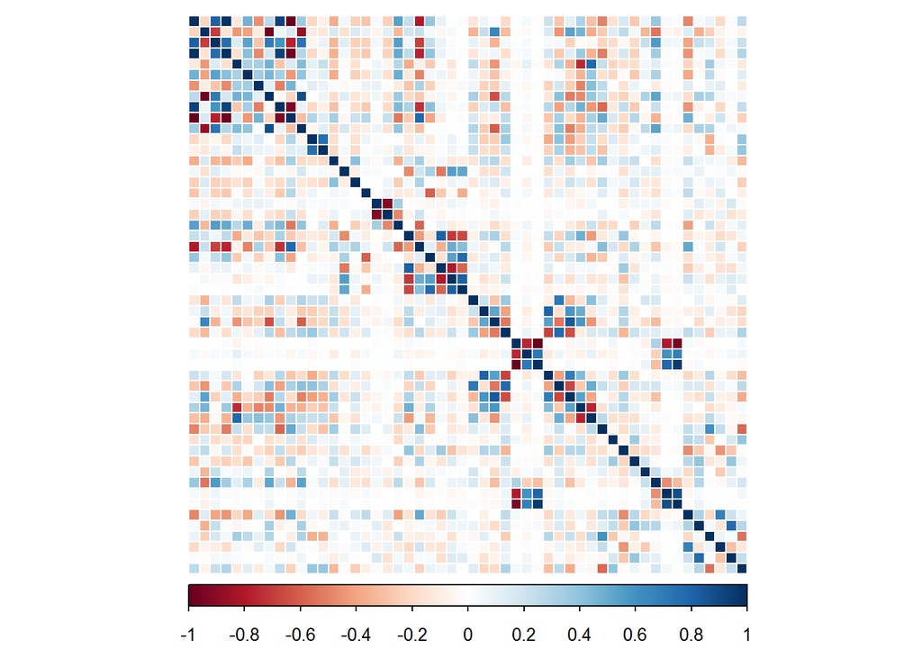

```r
library(corrplot)
corMat <- cor(subset(train, select=-c(classe)))
corrplot(corMat, method = "color", cl.pos = "b", tl.pos = "n")
```

Plotting the correlation matrix confirms that some variables are heavily correlated (dark blue and dark red squares). So it is possible to reduce the number of variables (and computation time) by applying Principal Component Analysis.

Perform PCA on all predictors (except the output “classe”) and get the number of principal components necessary for retaining 95% of the variance:

```r
preProc.pca <- preProcess(subset(train, select = -c(classe)), method  = "pca", thresh = 0.95)
train.pca <- predict(preProc.pca, subset(train, select = -c(classe)))
valid.pca <- predict(preProc.pca, subset(valid, select = -c(classe)))
test.pca <- predict(preProc.pca, subset(test, select = -c(problem_id)))
print(preProc.pca)
```

```
##
## Call:
## preProcess.default(x = subset(train, select = -c(classe)), method =
##  "pca", thresh = 0.95)
##
## Created from 11776 samples and 52 variables
## Pre-processing: principal component signal extraction, scaled, centered
##
## PCA needed 25 components to capture 95 percent of the variance
```

# Train Random Forest Model

Now train a Random Forest model using cross-validation and the reduced data from PCA.

Random Forest was chosen as it offers the following benefits:

- Accuracy
- Runs efficiently on large data bases
- Handles thousands of input variables without variable deletion
- Gives estimates of what variables are important in the classification

```r
library(randomForest)
modelFit <- train(train$classe ~ ., method = "rf", trControl = trainControl(method = "cv"), data = train.pca)
modelFit
```

```
## Random Forest
##
## 11776 samples
##    24 predictor
##     5 classes: 'A', 'B', 'C', 'D', 'E'
##
## No pre-processing
## Resampling: Cross-Validated (10 fold)
##
## Summary of sample sizes: 10598, 10597, 10598, 10598, 10601, 10598, ...
##
## Resampling results across tuning parameters:
##
##   mtry  Accuracy   Kappa      Accuracy SD  Kappa SD
##    2    0.9679884  0.9595010  0.006043591  0.007649452
##   13    0.9623836  0.9524134  0.005485208  0.006943893
##   25    0.9573725  0.9460700  0.004663825  0.005920765
##
## Accuracy was used to select the optimal model using  the largest value.
## The final value used for the model was mtry = 2.
```

# Assess Model Performance on Validation Dataset

Apply model to validation data and display confusion matrix:

```r
valid.pred <- predict(modelFit, valid.pca)
confusionMatrix(valid.pred, valid$classe)
```

```
## Confusion Matrix and Statistics
##
##           Reference
## Prediction    A    B    C    D    E
##          A 2212   28    6    4    1
##          B    7 1461   21    0    9
##          C    7   21 1328   49   14
##          D    5    0   10 1229   10
##          E    1    8    3    4 1408
##
## Overall Statistics
##
##                Accuracy : 0.9735
##                  95% CI : (0.9697, 0.9769)
##     No Information Rate : 0.2845
##     P-Value [Acc > NIR] : < 2.2e-16
##
##                   Kappa : 0.9665
##  Mcnemar's Test P-Value : NA
##
## Statistics by Class:
##
##                      Class: A Class: B Class: C Class: D Class: E
## Sensitivity            0.9910   0.9625   0.9708   0.9557   0.9764
## Specificity            0.9931   0.9942   0.9860   0.9962   0.9975
## Pos Pred Value         0.9827   0.9753   0.9359   0.9801   0.9888
## Neg Pred Value         0.9964   0.9910   0.9938   0.9914   0.9947
## Prevalence             0.2845   0.1935   0.1744   0.1639   0.1838
## Detection Rate         0.2819   0.1862   0.1693   0.1566   0.1795
## Detection Prevalence   0.2869   0.1909   0.1809   0.1598   0.1815
## Balanced Accuracy      0.9920   0.9783   0.9784   0.9759   0.9870
```

Out-of-Sample Error (OoSE) is defined as `1 - Accuracy`:

```r
1 - as.numeric(confusionMatrix(valid$classe, valid.pred)$overall[1])
```

```
## [1] 0.02651032
```

So we get an OoSE of 2.65%, which is pretty good.

# Assess Model Performance on Test Dataset

Finally, apply model to 20 test cases:

```r
test.pred <- predict(modelFit, test.pca)
test.pred
```

```
##  [1] B A A A A E D B A A B C B A E E A B B B
## Levels: A B C D E
```

This model scored 100% in the submission page, meaning all test cases were predicted successfully.